# Lab 4

March 2, 2018

RStudio keeps track of the code chunks in the document (see the menu near the bottom left of the code window, to the right of the “line number:column number” counter). Optionally, you can give any chunk a name, for instance “Setup” below. This can make it easier to navigate the code chunks afterwards.

# Data wrangling

## 1

Let us first inspect the two data sets

```r
stores
```

| date | phid | chain | storesize | sale | nobs | packages | market |
| --- | --- | --- | --- | --- | --- | --- | --- |
| 2004-03-01 | 1 | 1 | 450 | 2061176.6 | 4358 | 6029.900 | 0 |
| 2004-03-01 | 2 | 2 | 539 | 1850057.4 | 3999 | 5971.000 | 1 |
| 2004-03-01 | 3 | 1 | 419 | 787220.7 | 1773 | 2359.000 | 2 |
| 2004-03-01 | 4 | 3 | 583 | 1493831.8 | 2567 | 3654.106 | 3 |
| 2004-03-01 | 5 | 2 | 257 | 1249405.1 | 2514 | 3552.300 | 3 |
| 2004-03-01 | 6 | 2 | 273 | 1822493.5 | 3601 | 5292.506 | 3 |
| 2004-03-01 | 11 | 1 | 122 | 1184325.7 | 2752 | 3764.821 | 5 |
| 2004-03-01 | 12 | 3 | 400 | 2241024.9 | 4796 | 6431.000 | 6 |
| 2004-03-01 | 14 | 2 | 105 | 496317.1 | 1035 | 1307.800 | 7 |
| 2004-03-01 | 15 | 2 | 156 | 650308.2 | 1561 | 2143.286 | 8 |

[output cut: 990 more lines]

```r
markets
```

| year | market | area | f0_19 | f20_66 | f67 | m0_19 | m20_66 | m67 |
| --- | --- | --- | --- | --- | --- | --- | --- | --- |
| 2004 | 0 | 10.640 | 2095.0 | 4731.0 | 1265.0 | 2109.0 | 4767.0 | 907.0 |
| 2005 | 0 | 10.640 | 2065.0 | 4768.0 | 1303.0 | 2124.0 | 4784.0 | 933.0 |
| 2006 | 0 | 10.760 | 2034.0 | 4738.0 | 1315.0 | 2091.0 | 4786.0 | 946.0 |
| 2007 | 0 | 10.800 | 2006.0 | 4721.0 | 1327.0 | 2056.0 | 4961.0 | 973.0 |
| 2008 | 0 | 10.860 | 1998.0 | 4722.0 | 1352.0 | 2091.0 | 4824.0 | 993.0 |
| 2009 | 0 | 10.870 | 1975.0 | 4722.0 | 1375.0 | 2070.0 | 4775.0 | 1006.0 |
| 2010 | 0 | 10.925 | 1959.0 | 4736.5 | 1396.5 | 2059.5 | 4781.5 | 1039.0 |
| 2011 | 0 | 10.980 | 1943.0 | 4751.0 | 1418.0 | 2049.0 | 4788.0 | 1072.0 |
| 2004 | 1 | 9.940 | 1980.0 | 3779.0 | 635.0 | 2005.0 | 3877.0 | 380.0 |
| 2005 | 1 | 9.970 | 1953.0 | 3798.0 | 648.0 | 2056.0 | 3887.0 | 401.0 |

[output cut: 990 more lines]

We want to combine the information in the two data sets. More specifically, we want to add information about the market to each row in the stores data frame. This is achieved by an left join. In order to perform the join we need to extract the year rom the stores data, since we will join using the combination of market and year as key.

```r
stores <- mutate(stores, year = year(date))
stores
```

| date | phid | chain | storesize | sale | nobs | packages | market | year |
| --- | --- | --- | --- | --- | --- | --- | --- | --- |
| 2004-03-01 | 1 | 1 | 450 | 2061176.6 | 4358 | 6029.900 | 0 | 2004 |
| 2004-03-01 | 2 | 2 | 539 | 1850057.4 | 3999 | 5971.000 | 1 | 2004 |
| 2004-03-01 | 3 | 1 | 419 | 787220.7 | 1773 | 2359.000 | 2 | 2004 |
| 2004-03-01 | 4 | 3 | 583 | 1493831.8 | 2567 | 3654.106 | 3 | 2004 |
| 2004-03-01 | 5 | 2 | 257 | 1249405.1 | 2514 | 3552.300 | 3 | 2004 |
| 2004-03-01 | 6 | 2 | 273 | 1822493.5 | 3601 | 5292.506 | 3 | 2004 |
| 2004-03-01 | 11 | 1 | 122 | 1184325.7 | 2752 | 3764.821 | 5 | 2004 |
| 2004-03-01 | 12 | 3 | 400 | 2241024.9 | 4796 | 6431.000 | 6 | 2004 |
| 2004-03-01 | 14 | 2 | 105 | 496317.1 | 1035 | 1307.800 | 7 | 2004 |
| 2004-03-01 | 15 | 2 | 156 | 650308.2 | 1561 | 2143.286 | 8 | 2004 |

[output cut: 990 more lines]

```r
stores <- left_join(stores, markets, by = c("market", "year"))
stores
```

| date | phid | chain | storesize | sale | nobs | packages | market | year | area | f0_19 | f20_66 | f67 | m0_19 | m20_66 | m67 |
| --- | --- | --- | --- | --- | --- | --- | --- | --- | --- | --- | --- | --- | --- | --- | --- |
| 2004-03-01 | 1 | 1 | 450 | 2061176.6 | 4358 | 6029.900 | 0 | 2004 | 10.64 | 2095 | 4731 | 1265 | 2109 | 4767 | 907 |
| 2004-03-01 | 2 | 2 | 539 | 1850057.4 | 3999 | 5971.000 | 1 | 2004 | 9.94 | 1980 | 3779 | 635 | 2005 | 3877 | 380 |
| 2004-03-01 | 3 | 1 | 419 | 787220.7 | 1773 | 2359.000 | 2 | 2004 | 2.31 | 417 | 958 | 258 | 425 | 1036 | 185 |
| 2004-03-01 | 4 | 3 | 583 | 1493831.8 | 2567 | 3654.106 | 3 | 2004 | 99.32 | 19149 | 43835 | 11054 | 20237 | 43824 | 7364 |
| 2004-03-01 | 5 | 2 | 257 | 1249405.1 | 2514 | 3552.300 | 3 | 2004 | 99.32 | 19149 | 43835 | 11054 | 20237 | 43824 | 7364 |
| 2004-03-01 | 6 | 2 | 273 | 1822493.5 | 3601 | 5292.506 | 3 | 2004 | 99.32 | 19149 | 43835 | 11054 | 20237 | 43824 | 7364 |
| 2004-03-01 | 11 | 1 | 122 | 1184325.7 | 2752 | 3764.821 | 5 | 2004 | 0.67 | 78 | 170 | 86 | 73 | 183 | 36 |
| 2004-03-01 | 12 | 3 | 400 | 2241024.9 | 4796 | 6431.000 | 6 | 2004 | 143.11 | 35568 | 84281 | 20535 | 37438 | 85238 | 13218 |
| 2004-03-01 | 14 | 2 | 105 | 496317.1 | 1035 | 1307.800 | 7 | 2004 | 3.87 | 381 | 698 | 187 | 370 | 720 | 117 |
| 2004-03-01 | 15 | 2 | 156 | 650308.2 | 1561 | 2143.286 | 8 | 2004 | 11.60 | 2504 | 6230 | 1817 | 2658 | 6478 | 1100 |

[output cut: 990 more lines]

A `left_join(x,y, by = key)` keeps all observations in “X”. A right join would keep all observations in “y”, while a full join would keep all observations in “x” and “y”. For more information, see chapter 13 in R for Data Science.

## 2

We want to create a variable with the number of pharmacies in a given market in a given month. First, let us confirm that our data sets contain at most one observation per pharmacy per month

```r
count(stores, date, phid) %>% summarise(max(n))
```

| max(n) |
| --- |
| 1 |

```r
#Alternatively, we could do
group_by(stores, date, phid) %>% summarise(n = n()) %>% summarise(max(n))
```

| date | max(n) |
| --- | --- |
| 2004-03-01 | 1 |
| 2004-04-01 | 1 |
| 2004-05-01 | 1 |
| 2004-06-01 | 1 |
| 2004-07-01 | 1 |
| 2004-08-01 | 1 |
| 2004-09-01 | 1 |
| 2004-10-01 | 1 |
| 2004-11-01 | 1 |
| 2004-12-01 | 1 |

[output cut: 84 more lines]

Now, let us count the number of pharmacies per market (in a given month)

```r
stores <- group_by(stores, date, market) %>% mutate(ncomp = n()) %>% ungroup()
stores
```

| date | phid | chain | storesize | sale | nobs | packages | market | year | area | f0_19 | f20_66 | f67 | m0_19 | m20_66 | m67 | ncomp |
| --- | --- | --- | --- | --- | --- | --- | --- | --- | --- | --- | --- | --- | --- | --- | --- | --- |
| 2004-03-01 | 1 | 1 | 450 | 2061176.6 | 4358 | 6029.900 | 0 | 2004 | 10.64 | 2095 | 4731 | 1265 | 2109 | 4767 | 907 | 1 |
| 2004-03-01 | 2 | 2 | 539 | 1850057.4 | 3999 | 5971.000 | 1 | 2004 | 9.94 | 1980 | 3779 | 635 | 2005 | 3877 | 380 | 2 |
| 2004-03-01 | 3 | 1 | 419 | 787220.7 | 1773 | 2359.000 | 2 | 2004 | 2.31 | 417 | 958 | 258 | 425 | 1036 | 185 | 1 |
| 2004-03-01 | 4 | 3 | 583 | 1493831.8 | 2567 | 3654.106 | 3 | 2004 | 99.32 | 19149 | 43835 | 11054 | 20237 | 43824 | 7364 | 19 |
| 2004-03-01 | 5 | 2 | 257 | 1249405.1 | 2514 | 3552.300 | 3 | 2004 | 99.32 | 19149 | 43835 | 11054 | 20237 | 43824 | 7364 | 19 |
| 2004-03-01 | 6 | 2 | 273 | 1822493.5 | 3601 | 5292.506 | 3 | 2004 | 99.32 | 19149 | 43835 | 11054 | 20237 | 43824 | 7364 | 19 |
| 2004-03-01 | 11 | 1 | 122 | 1184325.7 | 2752 | 3764.821 | 5 | 2004 | 0.67 | 78 | 170 | 86 | 73 | 183 | 36 | 1 |
| 2004-03-01 | 12 | 3 | 400 | 2241024.9 | 4796 | 6431.000 | 6 | 2004 | 143.11 | 35568 | 84281 | 20535 | 37438 | 85238 | 13218 | 27 |
| 2004-03-01 | 14 | 2 | 105 | 496317.1 | 1035 | 1307.800 | 7 | 2004 | 3.87 | 381 | 698 | 187 | 370 | 720 | 117 | 1 |
| 2004-03-01 | 15 | 2 | 156 | 650308.2 | 1561 | 2143.286 | 8 | 2004 | 11.60 | 2504 | 6230 | 1817 | 2658 | 6478 | 1100 | 5 |

[output cut: 990 more lines]

```r
summarise(stores, mean = mean(ncomp), min = min(ncomp), max = max(ncomp))
```

| mean | min | max |
| --- | --- | --- |
| 14.19064 | 1 | 42 |

## 3

```r
stores <- mutate(stores,totpop = f0_19 + f20_66 + f67 +m0_19 + m20_66 + m67) %>%  mutate(popdens = totpop / area)
stores
```

| date | phid | chain | storesize | sale | nobs | packages | market | year | area | f0_19 | f20_66 | f67 | m0_19 | m20_66 | m67 | ncomp | totpop | popdens |
| --- | --- | --- | --- | --- | --- | --- | --- | --- | --- | --- | --- | --- | --- | --- | --- | --- | --- | --- |
| 2004-03-01 | 1 | 1 | 450 | 2061176.6 | 4358 | 6029.900 | 0 | 2004 | 10.64 | 2095 | 4731 | 1265 | 2109 | 4767 | 907 | 1 | 15874 | 1491.9173 |
| 2004-03-01 | 2 | 2 | 539 | 1850057.4 | 3999 | 5971.000 | 1 | 2004 | 9.94 | 1980 | 3779 | 635 | 2005 | 3877 | 380 | 2 | 12656 | 1273.2394 |
| 2004-03-01 | 3 | 1 | 419 | 787220.7 | 1773 | 2359.000 | 2 | 2004 | 2.31 | 417 | 958 | 258 | 425 | 1036 | 185 | 1 | 3279 | 1419.4805 |
| 2004-03-01 | 4 | 3 | 583 | 1493831.8 | 2567 | 3654.106 | 3 | 2004 | 99.32 | 19149 | 43835 | 11054 | 20237 | 43824 | 7364 | 19 | 145463 | 1464.5892 |
| 2004-03-01 | 5 | 2 | 257 | 1249405.1 | 2514 | 3552.300 | 3 | 2004 | 99.32 | 19149 | 43835 | 11054 | 20237 | 43824 | 7364 | 19 | 145463 | 1464.5892 |
| 2004-03-01 | 6 | 2 | 273 | 1822493.5 | 3601 | 5292.506 | 3 | 2004 | 99.32 | 19149 | 43835 | 11054 | 20237 | 43824 | 7364 | 19 | 145463 | 1464.5892 |
| 2004-03-01 | 11 | 1 | 122 | 1184325.7 | 2752 | 3764.821 | 5 | 2004 | 0.67 | 78 | 170 | 86 | 73 | 183 | 36 | 1 | 626 | 934.3284 |
| 2004-03-01 | 12 | 3 | 400 | 2241024.9 | 4796 | 6431.000 | 6 | 2004 | 143.11 | 35568 | 84281 | 20535 | 37438 | 85238 | 13218 | 27 | 276278 | 1930.5290 |
| 2004-03-01 | 14 | 2 | 105 | 496317.1 | 1035 | 1307.800 | 7 | 2004 | 3.87 | 381 | 698 | 187 | 370 | 720 | 117 | 1 | 2473 | 639.0181 |
| 2004-03-01 | 15 | 2 | 156 | 650308.2 | 1561 | 2143.286 | 8 | 2004 | 11.60 | 2504 | 6230 | 1817 | 2658 | 6478 | 1100 | 5 | 20787 | 1791.9828 |

[output cut: 990 more lines]

# Present and understand your data

## 4

The “sale” variable is in NOK. More convenient to have it in million NOK

```r
stores <- mutate(stores, sale = sale / 1000000)
```

```r
numvars <- select(stores, storesize, sale, nobs, packages, year, ncomp, totpop, popdens)
stargazer(as.data.frame(numvars), type = 'text')
```

```
===========================================================
Statistic   N       Mean     St. Dev.     Min       Max
-----------------------------------------------------------
storesize 33,886  254.109     177.967      0       1,967
sale      33,886   1.105       0.743    0.0001     9.127
nobs      33,886 2,590.153   1,511.958     1      27,999
packages  33,886 3,334.062   1,700.542   1.000  22,052.980
year      33,886 2,007.796     2.242     2,004     2,011
ncomp     33,886   14.191     13.766       1        42
totpop    33,886 94,277.860 103,054.000 439.000 305,910.000
popdens   33,886 1,459.083    512.215   453.767  2,449.469
-----------------------------------------------------------
```

For categorical variables with few values, tabulation is more useful

```r
count(stores, chain)
```

| chain | n |
| --- | --- |
| 1 | 11218 |
| 2 | 13147 |
| 3 | 6634 |
| 4 | 1289 |
| 5 | 1598 |

For categorical variables with many values, such as “phid” tabulation is more difficult. At least it is good to know the number of distinct observations

```r
summarise(stores, min_phid = min(phid), max_phid = max(phid), distinct_phid = n_distinct(phid))
```

| min_phid | max_phid | distinct_phid |
| --- | --- | --- |
| 1 | 726 | 433 |

## 5

When we have many observations, a plain-vanilla scatter is not that informative:

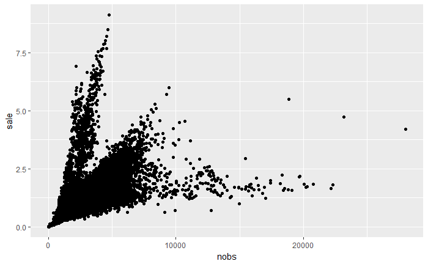

```r
ggplot(data = stores) +
  geom_point(mapping = aes(x = nobs, y = sale))
```

Making the points partially transparent helps a bit (but not that much):

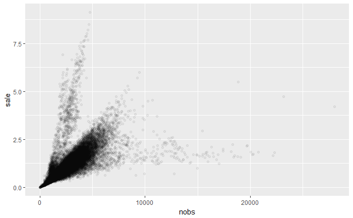

```r
ggplot(data = stores) +
  geom_point(mapping = aes(x = nobs, y = sale), alpha = .05)
```

A useful variant of a scatter plot is a binscatter (available through the `statar` package). A binscatter plots average values of the y-variable for within bins of the x-variable:

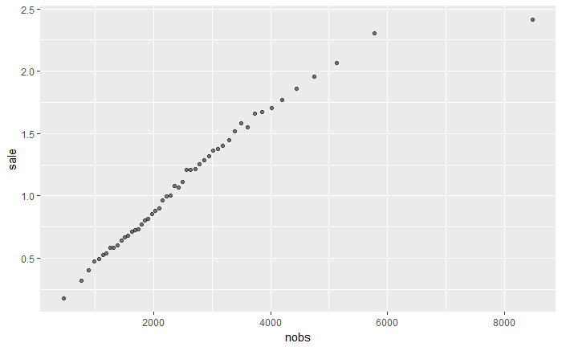

```r
ggplot(data = stores, mapping = aes(x = nobs, y = sale)) +
  stat_binmean(n = 50, alpha = 0.5)
```

We could also do something similar “manually”:

```r
stores <- mutate(stores, nobsgroup = cut(nobs, breaks = seq(0, 9000, by = 1000)))
stores
```

| date | phid | chain | storesize | sale | nobs | packages | market | year | area | f0_19 | f20_66 | f67 | m0_19 | m20_66 | m67 | ncomp | totpop | popdens | nobsgroup |
| --- | --- | --- | --- | --- | --- | --- | --- | --- | --- | --- | --- | --- | --- | --- | --- | --- | --- | --- | --- |
| 2004-03-01 | 1 | 1 | 450 | 2.0611766 | 4358 | 6029.900 | 0 | 2004 | 10.64 | 2095 | 4731 | 1265 | 2109 | 4767 | 907 | 1 | 15874 | 1491.9173 | (4e+03,5e+03] |
| 2004-03-01 | 2 | 2 | 539 | 1.8500574 | 3999 | 5971.000 | 1 | 2004 | 9.94 | 1980 | 3779 | 635 | 2005 | 3877 | 380 | 2 | 12656 | 1273.2394 | (3e+03,4e+03] |
| 2004-03-01 | 3 | 1 | 419 | 0.7872207 | 1773 | 2359.000 | 2 | 2004 | 2.31 | 417 | 958 | 258 | 425 | 1036 | 185 | 1 | 3279 | 1419.4805 | (1e+03,2e+03] |
| 2004-03-01 | 4 | 3 | 583 | 1.4938318 | 2567 | 3654.106 | 3 | 2004 | 99.32 | 19149 | 43835 | 11054 | 20237 | 43824 | 7364 | 19 | 145463 | 1464.5892 | (2e+03,3e+03] |
| 2004-03-01 | 5 | 2 | 257 | 1.2494051 | 2514 | 3552.300 | 3 | 2004 | 99.32 | 19149 | 43835 | 11054 | 20237 | 43824 | 7364 | 19 | 145463 | 1464.5892 | (2e+03,3e+03] |
| 2004-03-01 | 6 | 2 | 273 | 1.8224935 | 3601 | 5292.506 | 3 | 2004 | 99.32 | 19149 | 43835 | 11054 | 20237 | 43824 | 7364 | 19 | 145463 | 1464.5892 | (3e+03,4e+03] |
| 2004-03-01 | 11 | 1 | 122 | 1.1843257 | 2752 | 3764.821 | 5 | 2004 | 0.67 | 78 | 170 | 86 | 73 | 183 | 36 | 1 | 626 | 934.3284 | (2e+03,3e+03] |
| 2004-03-01 | 12 | 3 | 400 | 2.2410249 | 4796 | 6431.000 | 6 | 2004 | 143.11 | 35568 | 84281 | 20535 | 37438 | 85238 | 13218 | 27 | 276278 | 1930.5290 | (4e+03,5e+03] |
| 2004-03-01 | 14 | 2 | 105 | 0.4963171 | 1035 | 1307.800 | 7 | 2004 | 3.87 | 381 | 698 | 187 | 370 | 720 | 117 | 1 | 2473 | 639.0181 | (1e+03,2e+03] |
| 2004-03-01 | 15 | 2 | 156 | 0.6503082 | 1561 | 2143.286 | 8 | 2004 | 11.60 | 2504 | 6230 | 1817 | 2658 | 6478 | 1100 | 5 | 20787 | 1791.9828 | (1e+03,2e+03] |

[output cut: 990 more lines]

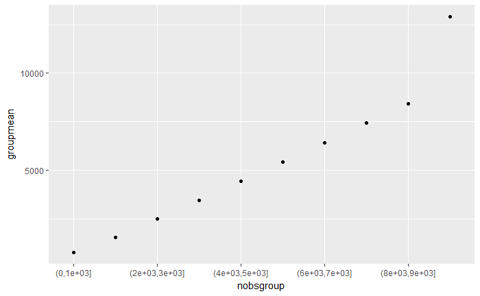

```r
group_by(stores, nobsgroup) %>% summarise(groupmean = mean(nobs))  %>%
ggplot() +
  geom_point(mapping = aes(x = nobsgroup, y = groupmean)) +
  scale_x_discrete(breaks=function(x) x[seq(1, length(x), by=2)])
```

Turning now to number of pharmacies in the market:

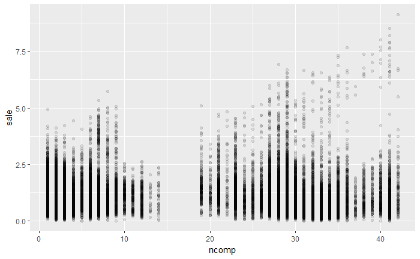

```r
ggplot(data = stores ) +
  geom_point(mapping = aes(x = ncomp, y = sale), alpha = 0.1)
```

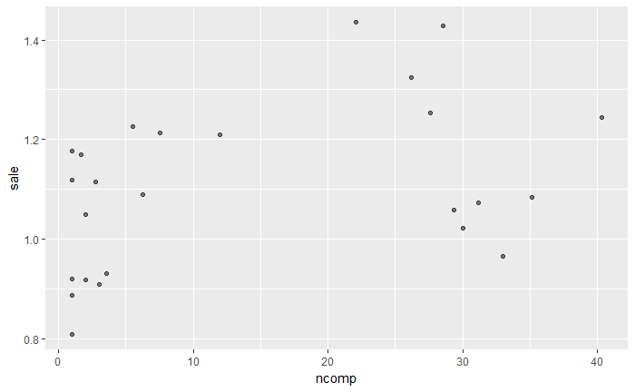

```r
ggplot(data = stores, mapping = aes(x = ncomp, y = sale)) +
  stat_binmean(n = 25, alpha = 0.5)
```

## 6

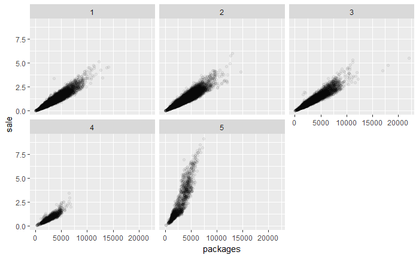

```r
ggplot(data = stores) +
  geom_point(mapping = aes(x = packages, y = sale ), alpha = 0.05) +
  facet_wrap(~ chain)
```

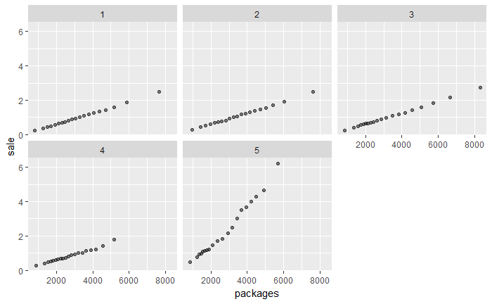

```r
ggplot(data = stores, aes(x = packages, y = sale )) +
  stat_binmean(n = 20, alpha = 0.5) +
  facet_wrap(~ chain)
```

# Estimation

## 7

As usual we run OLS regressions with the command `lm`:

```r
salereg_ncomp <- lm(sale ~ ncomp, data = stores)
stargazer(salereg_ncomp, type = 'text',
          dep.var.labels = "Sales in million NOK",
          covariate.labels = "Number of pharmacies in market")
```

```
==========================================================
                                   Dependent variable:
                               ---------------------------
                                  Sales in million NOK
----------------------------------------------------------
Number of pharmacies in market          0.005***
                                        (0.0003)

Constant                                1.036***
                                         (0.006)

----------------------------------------------------------
Observations                             33,886
R2                                        0.008
Adjusted R2                               0.008
Residual Std. Error                0.740 (df = 33884)
F Statistic                    282.049*** (df = 1; 33884)
==========================================================
Note:                          *p<0.1; **p<0.05; ***p<0.01
```

There is a possible relationship between sales and number of competitors in the market. Of course, we should not give this regression a causal interpretation.

## 8

```r
stores <- group_by(stores, phid) %>%
  mutate(demeaned_sale = sale - mean(sale), demeaned_ncomp = ncomp - mean(ncomp)) %>%
  ungroup()
```

## 9

As before, an ordinary scatter is difficult to read

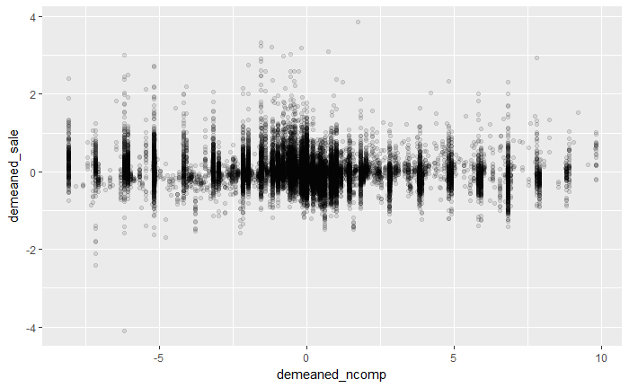

```r
ggplot(data = stores ) +
  geom_point(mapping = aes(x = demeaned_ncomp, y = demeaned_sale), alpha = 0.1)
```

A binscatter:

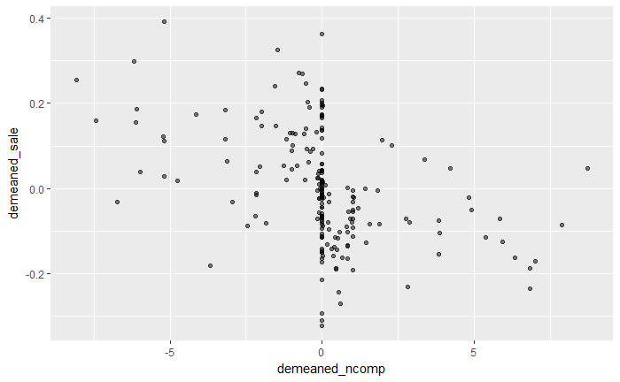

```r
ggplot(data = stores, mapping = aes(x = demeaned_ncomp, y = demeaned_sale)) +
  stat_binmean(n = 200, alpha = 0.5)
```

## 10

```r
salereg_ncomp <- lm(demeaned_sale ~ demeaned_ncomp, data = stores)
stargazer(salereg_ncomp, type = 'text',
          dep.var.labels = "Sales in million NOK (demeaned)",
          covariate.labels = "Number of pharmacies in market (demeaned)",
          notes = "Variables are demeaned with respect to pharmacy-level means")
```

```
=====================================================================================================
                                                              Dependent variable:
                                          -----------------------------------------------------------
                                                        Sales in million NOK (demeaned)
-----------------------------------------------------------------------------------------------------
Number of pharmacies in market (demeaned)                          -0.023***
                                                                    (0.001)

Constant                                                             0.000
                                                                    (0.002)

-----------------------------------------------------------------------------------------------------
Observations                                                        33,886
R2                                                                   0.028
Adjusted R2                                                          0.028
Residual Std. Error                                           0.328 (df = 33884)
F Statistic                                               979.803*** (df = 1; 33884)
=====================================================================================================
Note:                                                                     *p<0.1; **p<0.05; ***p<0.01
                                          Variables are demeaned with respect to pharmacy-level means
```

## 11

First, we need to create a panel structure for our data set

```r
stores_panel = pdata.frame(stores, index=c("phid", "date"))
pdim(stores_panel)
```

```
Unbalanced Panel: n = 433, T = 1-94, N = 33886
```

We have observations for 433 pharmacies in 94 months. The panel is unbalanced, which means that not all pharmacies are observed in all periods. (Why could that be?) Fixed effects (“whithin”) estimatoin is done with the `plm` package.

```r
salereg_ncomp_fe <- plm(sale ~ ncomp, data = stores_panel, model = 'within')
stargazer(salereg_ncomp_fe, type = 'text',
          dep.var.labels = "Sales in million NOK",
          covariate.labels = "Number of pharmacies in market"
          )
```

```
the condition has length > 1 and only the first element will be used
```

```
==========================================================
                                   Dependent variable:
                               ---------------------------
                                  Sales in million NOK
----------------------------------------------------------
Number of pharmacies in market          -0.023***
                                         (0.001)

----------------------------------------------------------
Observations                             33,886
R2                                        0.028
Adjusted R2                               0.016
F Statistic                    967.311*** (df = 1; 33452)
==========================================================
Note:                          *p<0.1; **p<0.05; ***p<0.01
```

We see that the results are the same as in task 10 (which is just a manual way of implementing the fixed effects regression). The result is very different from the simple OLS in task 7: the estimated coefficient has the opposite sign.

## 12

A regression with market-level fixed effects can be implemented bt adding dummies for the markets (and then running an OLS-regression).

```r
salereg_ncomp_market_fe <- lm(sale ~ ncomp + factor(market), data = stores)
stargazer(salereg_ncomp_market_fe, type = 'text',
          dep.var.labels = "Sales in million NOK",
          covariate.labels = "Number of pharmacies in market",
          keep = "ncomp",
          notes = "Dummy variables for markets included in the regression but excluded from table"
          )
```

```
=============================================================================================================
                                                            Dependent variable:
                               ------------------------------------------------------------------------------
                                                            Sales in million NOK
-------------------------------------------------------------------------------------------------------------
Number of pharmacies in market                                   -0.046***
                                                                  (0.001)

-------------------------------------------------------------------------------------------------------------
Observations                                                       33,886
R2                                                                 0.151
Adjusted R2                                                        0.148
Residual Std. Error                                          0.686 (df = 33759)
F Statistic                                             47.771*** (df = 126; 33759)
=============================================================================================================
Note:                                                                             *p<0.1; **p<0.05; ***p<0.01
                               Dummy variables for markets included in the regression but excluded from table
```

The negative effect of more competitors on sales is now estimated to be even stronger.

# Extra

## a

```r
market_years <- group_by(stores, year, market) %>%
  summarise(ncomp = mean(ncomp),
            totpop = mean(totpop))
```

```r
market_years <- left_join(market_years, markets, by = c("year","market"))
market_years
```

| year | market | ncomp | totpop | area | f0_19 | f20_66 | f67 | m0_19 | m20_66 | m67 |
| --- | --- | --- | --- | --- | --- | --- | --- | --- | --- | --- |
| 2004 | 0 | 1.000000 | 15874.0 | 10.640 | 2095.0 | 4731.0 | 1265.0 | 2109.0 | 4767.0 | 907.0 |
| 2004 | 1 | 2.000000 | 12656.0 | 9.940 | 1980.0 | 3779.0 | 635.0 | 2005.0 | 3877.0 | 380.0 |
| 2004 | 2 | 1.000000 | 3279.0 | 2.310 | 417.0 | 958.0 | 258.0 | 425.0 | 1036.0 | 185.0 |
| 2004 | 3 | 19.000000 | 145463.0 | 99.320 | 19149.0 | 43835.0 | 11054.0 | 20237.0 | 43824.0 | 7364.0 |
| 2004 | 5 | 1.000000 | 626.0 | 0.670 | 78.0 | 170.0 | 86.0 | 73.0 | 183.0 | 36.0 |
| 2004 | 6 | 27.408759 | 276278.0 | 143.110 | 35568.0 | 84281.0 | 20535.0 | 37438.0 | 85238.0 | 13218.0 |
| 2004 | 7 | 1.000000 | 2473.0 | 3.870 | 381.0 | 698.0 | 187.0 | 370.0 | 720.0 | 117.0 |
| 2004 | 8 | 5.000000 | 20787.0 | 11.600 | 2504.0 | 6230.0 | 1817.0 | 2658.0 | 6478.0 | 1100.0 |
| 2004 | 9 | 6.000000 | 38632.0 | 15.960 | 5067.0 | 12082.0 | 2250.0 | 5492.0 | 12204.0 | 1537.0 |
| 2004 | 10 | 1.000000 | 4341.0 | 3.020 | 578.0 | 1266.0 | 354.0 | 629.0 | 1264.0 | 250.0 |

[output cut: 982 more lines]

(Could also have summarized the population variables, but proposed method saves some typing.)

## b

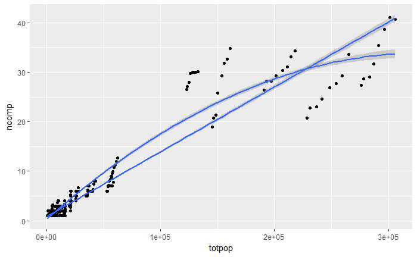

```r
ggplot(market_years, mapping = aes(x = totpop, y = ncomp)) +
  geom_point() +
  geom_smooth(formula = y ~ x, method='lm') +
  geom_smooth(formula = y ~ poly(x, 2), method = 'lm')
```

Market-years with large markets (high population) tend to hanve many competitors. The relationship seems to be concave. We expect a concave relionshiop between number of competitors and market size if more competitors leads to more intense competition (cf. the with the discussion in lecture 7, slide 29-30.)

## c

```r
market_years <- group_by(market_years, market) %>%
  mutate(demeaned_ncomp = ncomp - mean(ncomp), demeaned_totpop = totpop - mean(totpop)) %>%
  ungroup()
```

```r
market_years
```

| year | market | ncomp | totpop | area | f0_19 | f20_66 | f67 | m0_19 | m20_66 | m67 | demeaned_ncomp | demeaned_totpop |
| --- | --- | --- | --- | --- | --- | --- | --- | --- | --- | --- | --- | --- |
| 2004 | 0 | 1.000000 | 15874.0 | 10.640 | 2095.0 | 4731.0 | 1265.0 | 2109.0 | 4767.0 | 907.0 | -0.34134615 | -88.625000 |
| 2004 | 1 | 2.000000 | 12656.0 | 9.940 | 1980.0 | 3779.0 | 635.0 | 2005.0 | 3877.0 | 380.0 | -0.58467742 | -1161.687500 |
| 2004 | 2 | 1.000000 | 3279.0 | 2.310 | 417.0 | 958.0 | 258.0 | 425.0 | 1036.0 | 185.0 | 0.00000000 | 151.062500 |
| 2004 | 3 | 19.000000 | 145463.0 | 99.320 | 19149.0 | 43835.0 | 11054.0 | 20237.0 | 43824.0 | 7364.0 | -7.94770298 | -6931.937500 |
| 2004 | 5 | 1.000000 | 626.0 | 0.670 | 78.0 | 170.0 | 86.0 | 73.0 | 183.0 | 36.0 | 0.00000000 | 39.250000 |
| 2004 | 6 | 27.408759 | 276278.0 | 143.110 | 35568.0 | 84281.0 | 20535.0 | 37438.0 | 85238.0 | 13218.0 | -6.65258069 | -13627.875000 |
| 2004 | 7 | 1.000000 | 2473.0 | 3.870 | 381.0 | 698.0 | 187.0 | 370.0 | 720.0 | 117.0 | 0.00000000 | -80.625000 |
| 2004 | 8 | 5.000000 | 20787.0 | 11.600 | 2504.0 | 6230.0 | 1817.0 | 2658.0 | 6478.0 | 1100.0 | -0.77419355 | -58.687500 |
| 2004 | 9 | 6.000000 | 38632.0 | 15.960 | 5067.0 | 12082.0 | 2250.0 | 5492.0 | 12204.0 | 1537.0 | -0.96617978 | -2314.000000 |
| 2004 | 10 | 1.000000 | 4341.0 | 3.020 | 578.0 | 1266.0 | 354.0 | 629.0 | 1264.0 | 250.0 | -0.01923077 | -135.187500 |

[output cut: 982 more lines]

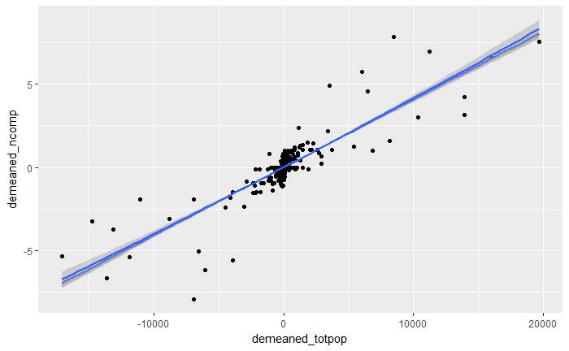

```r
ggplot(market_years, mapping = aes(x = demeaned_totpop, y = demeaned_ncomp)) +
  geom_point() +
  geom_smooth(formula = y ~ x, method='lm') +
  geom_smooth(formula = y ~ poly(x, 2), method = 'lm')
```

The relationship is similar as the one found in b). Within markets, there tends to be more competitors in periods where the market size is large (measured by population). This makes intuitive sense. Note however that the relationship is close to being linear.

## d

```r
ncomp_dem <- lm(ncomp ~  f0_19 + f20_66 + f67 + m0_19 + m20_66 + m67, data = market_years)
stargazer(ncomp_dem , type = 'text')
```

```
===============================================
                        Dependent variable:
                    ---------------------------
                               ncomp
-----------------------------------------------
f0_19                        -0.002**
                              (0.001)

f20_66                       0.001***
                             (0.0002)

f67                          -0.004***
                             (0.0004)

m0_19                          0.001
                              (0.001)

m20_66                       -0.001***
                             (0.0002)

m67                          0.009***
                              (0.001)

Constant                     0.595***
                              (0.040)

-----------------------------------------------
Observations                    992
R2                             0.963
Adjusted R2                    0.963
Residual Std. Error      1.095 (df = 985)
F Statistic         4,321.945*** (df = 6; 985)
===============================================
Note:               *p<0.1; **p<0.05; ***p<0.01
```

Not a very clear picture.

## e

A fixed effects estimation will indicate whether the y-variable is larger/smaller than the average (for the market) in periods where the x-variables are larger/smaller than average (for the market). It is therefore well suited for this task.

```r
market_panel = pdata.frame(market_years, index=c("market", "year"))
pdim(market_panel)
```

```
Unbalanced Panel: n = 126, T = 1-8, N = 992
```

We have an unbalanced panel with 126 markets and 8 periods (years).

```r
ncomp_pop_fe <- plm(ncomp ~  totpop, data = market_panel, model = 'within')
stargazer(ncomp_pop_fe, type = 'text')
```

```
the condition has length > 1 and only the first element will be used
```

```
========================================
                 Dependent variable:
             ---------------------------
                        ncomp
----------------------------------------
totpop                0.0004***
                      (0.00001)

----------------------------------------
Observations             992
R2                      0.713
Adjusted R2             0.671
F Statistic  2,150.404*** (df = 1; 865)
========================================
Note:        *p<0.1; **p<0.05; ***p<0.01
```

Increases in population seem to be assosiated with entry.

```r
ncomp_dem_fe <- plm(ncomp ~  f0_19 + f20_66 + f67 + m0_19 + m20_66 + m67, data = market_panel, model = 'within')
stargazer(ncomp_dem_fe, type = 'text')
```

```
the condition has length > 1 and only the first element will be used
```

```
========================================
                 Dependent variable:
             ---------------------------
                        ncomp
----------------------------------------
f0_19                 0.004***
                       (0.001)

f20_66                -0.002***
                      (0.0004)

f67                    0.002**
                       (0.001)

m0_19                 -0.004***
                       (0.001)

m20_66                0.002***
                      (0.0002)

m67                   0.005***
                       (0.001)

----------------------------------------
Observations             992
R2                      0.792
Adjusted R2             0.761
F Statistic   546.496*** (df = 6; 860)
========================================
Note:        *p<0.1; **p<0.05; ***p<0.01
```

More senior citizens are associated with entry. For other age groups, picture is not so clear.